# Machine Learning Course Project

Andrey ABRAMOV

April 27 2016

## 1. Intro

This Course Project is mainly about the project for Machine Learning provided by Johns Hopkins University (https://www.coursera.org/learn/practical-machine-learning/home/welcome).

The goal of our Course Project is to predict the same manner like Groupware@LES in which they did the Human Activity Recognition process. Human Activity Recognition - has emerged as a key research area in the last years and is gaining increasing attention by the pervasive computing research community.

## 2 Background

Groupware@LES proposed a dataset with 5 classes (sitting-down, standing-up, standing, walking, and sitting) collected on some hours of activities of 6 healthy subjects. This human activity recognition research has traditionally focused on discriminating between different activities, i.e. to predict “which” activity was performed at a specific point in time. The approach we propose for the Weight Lifting Exercises dataset is to investigate “how (well)” an activity was performed by the wearer.

In this work we will try to make the same steps and received the same result as Groupware@LES.

More information of Groupware@LES result is available from the website here: http://groupware.les.inf.puc-rio.br/har. The training data for this project are available here: https://d396qusza40orc.cloudfront.net/predmachlearn/pml-training.csv The test data are available here: https://d396qusza40orc.cloudfront.net/predmachlearn/pml-testing.csv

According to the description of the Course Project complete R code should not be provided with data describing the results of the calculations.

So let’s start step by step:

## 3 Formulation of idea

So, in order to achieve the same result, as colleagues from Groupware@LES group, clean received training Assembly from NA and null columns. All designation of a classes we will transform to numeric values.

We will take 15 appropriate methods for training our model on the training Assembly as the STEP 1. Calculate a result. Assume that all results will be not the best and we will need to proceed one more training operation. I will apply the same set of methods on the result of STEP 1 like the STEP 2. It will help us to reduce the variation in results and to improve the accuracy of the training.

## 4 Setting UP the calculation

Setting up libraries and working directory:

```r
library(caret)
library(doParallel) # for parallel calculation
library(plyr)
library(dplyr)
```

```r
library(ggplot2)
library(pander)
library(sqldf)
# please set up working directory !!
```

## 5 Load mentioned data set

Using direct link load two data sets:

```r
# training set
A.url <- "https://d396qusza40orc.cloudfront.net/predmachlearn/pml-training.csv"
download.file(A.url, "pml-training.csv")
A <- read.table(file="pml-training.csv", header = T, sep = ",")
# testing set
A.test.url <- "https://d396qusza40orc.cloudfront.net/predmachlearn/pml-testing.csv"
download.file(A.test.url, "pml-testing.csv")
A.test <- read.table(file="pml-testing.csv", header = T, sep = ",")
```

## 6 Cleaning Data Set

Collect al person names from the data set:

```r
A$user_name <- as.character(A$user_name)
personal.name = sqldf("SELECT user_name FROM A GROUP BY 1")
personal.name
```

```
##   user_name
## 1    adelmo
## 2  carlitos
## 3   charles
## 4    eurico
## 5    jeremy
## 6     pedro
```

We have just 6 personal data in the loaded data set.

Now clean the data sets of NA, Blunks and “#DIV/0!” items.

```r
Delete.Missed.Data <- function(x) #clean function
{
  index1 <- any(is.na(x))
  index2 <- any(which(x==""))
  any(index1, index2)
}

A <- A[,!apply(A, 2, Delete.Missed.Data)]
A.test <- A.test[,!apply(A.test, 2, Delete.Missed.Data)]

A <- A[,-c(1,3:7)] # delete some extra columns
A.test <- A.test[,-c(1,3:7)] # and from the test data set too
```

Replacing class chars by numeric:

```r
Class.As.Numeric <- function(x) {
  x$Group <- 0
  x$Group[which(x$classe=="A")] <- 1
  x$Group[which(x$classe=="B")] <- 2
  x$Group[which(x$classe=="C")] <- 3
  x$Group[which(x$classe=="D")] <- 4
  x$Group[which(x$classe=="E")] <- 5
  return(x)
}
A <- Class.As.Numeric(A)
```

## 7 Let’s check the idea. Calculation of STEP 1

Choose like for example 15 methods from the existing 180 and start the learning process.

```r
# setting up methods names
method.names <- c("enet", "foba", "gam", "gamLoess", "gbm", "glm",
                  "glmboost", "glmnet", "icr", "knn", "lars", "lars2", "lm", "rf", "spls")
methods.length <- length(method.names) # number of methods
# prepearing a place for result
# for training part
for (k in 1:methods.length) { # prepare the columns for the result
  A$x <- 0
  names(A)[names(A) == 'x'] <- paste0("X.", k)
}
# prepare the place for STEP 2 result
A$x <- 0
names(A)[names(A) == 'x'] <- "STEP.2"
# for testing part
A.test$classe <- ""
for (k in 1:methods.length) {
  A.test$x <- 0
  names(A.test)[names(A.test) == 'x'] <- paste0("X.", k)
}
A.test$x <- 0
names(A.test)[names(A.test) == 'x'] <- "STEP.2"

# create partitioning for training set
inTrain <- createDataPartition(y=A$classe, p=0.9, list=F)
B <- A[-inTrain, ] # part for checking the result of modeling
A <- A[inTrain, ] # part for training
```

Starting learning process for each personal name as STEP 1:

```
## [1] "1+ : enet"
```

```
## [1] "2+ : foba"
```

```
## [1] "3+ : gam"
```

```
## [1] "4+ : gamLoess"
```

[output not shown]

[output cut: 34 more lines]

[output not shown]

```
## [1] "5+ : gbm"
```

```
##
## [1] "6+ : glm"
## [1] "7+ : glmboost"
```

[output not shown]

```
## [1] "8+ : glmnet"
```

```
## [1] "9+ : icr"
```

```
## [1] "10+ : knn"
## [1] "11+ : lars"
## [1] "12+ : lars2"
## [1] "13+ : lm"
## [1] "14+ : rf"
```

```
## [1] "15+ : spls"
```

[output not shown]

## 8 Cross Validation & Quality Anlysis of STEP 1

Let’s prepare the middle calculation result:

```r
Middle.Result <- matrix(nrow = 5, ncol =methods.length+2) # result of STEP 1
Middle.Result <- as.data.frame(Middle.Result)
# names for two fisrt column
names(Middle.Result)[1] <- "Char.Group.Name"
names(Middle.Result)[2] <- "Num.Group.Name"
# fullfil names of our groups
Middle.Result$Num.Group.Name <- c(1:5)
Middle.Result$Char.Group.Name <- c("A", "B", "C", "D", "E")
# names for the rest of column
for (k in 1:methods.length) {
  names(Middle.Result)[k+2] <- paste0("X.", k)
  Middle.Result[ ,k+2] <- 0
}
Middle.Result_0 <- Middle.Result # save a copy of table
# calculate the middle result
limits <- matrix(nrow = 2, ncol = 5, data = c(c(0, 1.5), c(1.5, 2.5), c(2.5, 3.5), c(3.5, 4.5), c(4.5, 7))); limits <- as.data.frame(limits)
for (i in 1:methods.length) {
    for (j in 1:5) {
      A.selected <- A[which(A$Group==j), ]  # select the current group
      total.row <- nrow(A.selected) # total of the items
      A.selected <- A.selected[which(A.selected[, 55+i]>limits[1,j] & A.selected[, 55+i]<=limits[2,j] ), ] # select all in the range
      Middle.Result[j, 2+i] <- nrow(A.selected)/total.row # calculation of the result
    }
}
```

As the middle result we are receiving:

```r
Middle.Result2 <- Middle.Result
Middle.Result2 <- Middle.Result2[, -2]
add.to.MR2 <- c()
# i<-2
names(Middle.Result2)[1] <- "Group"
for (i in 1:methods.length) {
  names(Middle.Result2)[1+i] <- method.names[i]
  Middle.Result2[,1+i] <- Middle.Result2[,1+i]*100
  b <- sum(Middle.Result2[,1+i])/5
  add.to.MR2 <- cbind(add.to.MR2, b)
}
add.to.MR2 <- cbind("Average", add.to.MR2)
add.to.MR2 <- as.data.frame(add.to.MR2)
names(add.to.MR2) <- names(Middle.Result2)
for (i in 2:(methods.length+1)) { add.to.MR2[ ,i] <- as.numeric(as.character(add.to.MR2[ ,i]))}
Middle.Result2 <- rbind(Middle.Result2, add.to.MR2)
pander(Middle.Result2) #nice table with result
```

Table continues below

| Group | enet | foba | gam | gamLoess | gbm | glm |
| --- | --- | --- | --- | --- | --- | --- |
| A | 39.84 | 39.84 | 74.91 | 61.25 | 65.51 | 39.84 |
| B | 36.78 | 36.78 | 66.71 | 60.04 | 63.6 | 36.78 |
| C | 64.55 | 64.51 | 77.31 | 75.03 | 87.63 | 64.55 |
| D | 38.2 | 38.2 | 54.02 | 45.66 | 48.74 | 38.2 |
| E | 24.67 | 24.64 | 63.97 | 54.3 | 55.34 | 24.67 |
| Average | 40.81 | 40.8 | 67.38 | 59.26 | 64.17 | 40.81 |

Table continues below

| glmboost | glmnet | icr | knn | lars | lars2 | lm |
| --- | --- | --- | --- | --- | --- | --- |
| 23.08 | 27.08 | 0 | 94.21 | 39.84 | 35.56 | 39.84 |
| 29.05 | 33.7 | 18.11 | 87.77 | 36.78 | 38.94 | 36.78 |
| 77.05 | 74.81 | 70.42 | 95.06 | 64.55 | 67.95 | 64.55 |
| 12.37 | 31.36 | 1.727 | 93.13 | 38.2 | 38.13 | 38.2 |
| 1.54 | 10.75 | 0 | 82.94 | 24.67 | 20.36 | 24.67 |
| 28.62 | 35.54 | 18.05 | 90.62 | 40.81 | 40.19 | 40.81 |

| rf | spls |
| --- | --- |
| 99.84 | 31.16 |
| 99.97 | 29.05 |
| 100 | 68.6 |
| 100 | 33.44 |
| 99.82 | 4.835 |
| 99.93 | 33.42 |

as percent of accuracy by each training method.

And the STEP 2 result will be:

```r
  Middle.Result <- Middle.Result_0
  # calculate the STEP 2 result
  for (i in best.method:best.method) {
    for (j in 1:5) {
      A.selected <- A[which(A$Group==j), ]  # select the current group
      total.row <- nrow(A.selected)
      A.selected <- A.selected[which(A.selected$STEP.2>limits[1,j] & A.selected$STEP.2<=limits[2,j] ), ]
      Middle.Result[j, 2+i] <- nrow(A.selected)/total.row*100
    }
  }

  Middle.Result3 <- Middle.Result
  Middle.Result3 <- Middle.Result3[, -2]
  add.to.MR2 <- c()

  names(Middle.Result3)[1] <- "Group"
  for (i in 1:methods.length) {
    names(Middle.Result3)[1+i] <- method.names[i]
    Middle.Result3[,1+i] <- Middle.Result3[,1+i]
    b <- sum(Middle.Result3[,1+i])/5
    add.to.MR2 <- cbind(add.to.MR2, b)
  }
  add.to.MR2 <- cbind("Average", add.to.MR2)
  add.to.MR2 <- as.data.frame(add.to.MR2)
  names(add.to.MR2) <- names(Middle.Result3)
  for (i in 2:(methods.length+1)) { add.to.MR2[ ,i] <- as.numeric(as.character(add.to.MR2[ ,i]))}
  Middle.Result3 <- rbind(Middle.Result3, add.to.MR2)
  Middle.Result3 <- Middle.Result3[ , c(1,best.method+1) ]

  pander(Middle.Result3)
```

| Group | rf |
| --- | --- |
| A | 100 |
| B | 100 |
| C | 100 |
| D | 100 |
| E | 100 |
| Average | 100 |

So. The result is not bad. Let’s check it on the test data set. Hereafter the plot of the result:

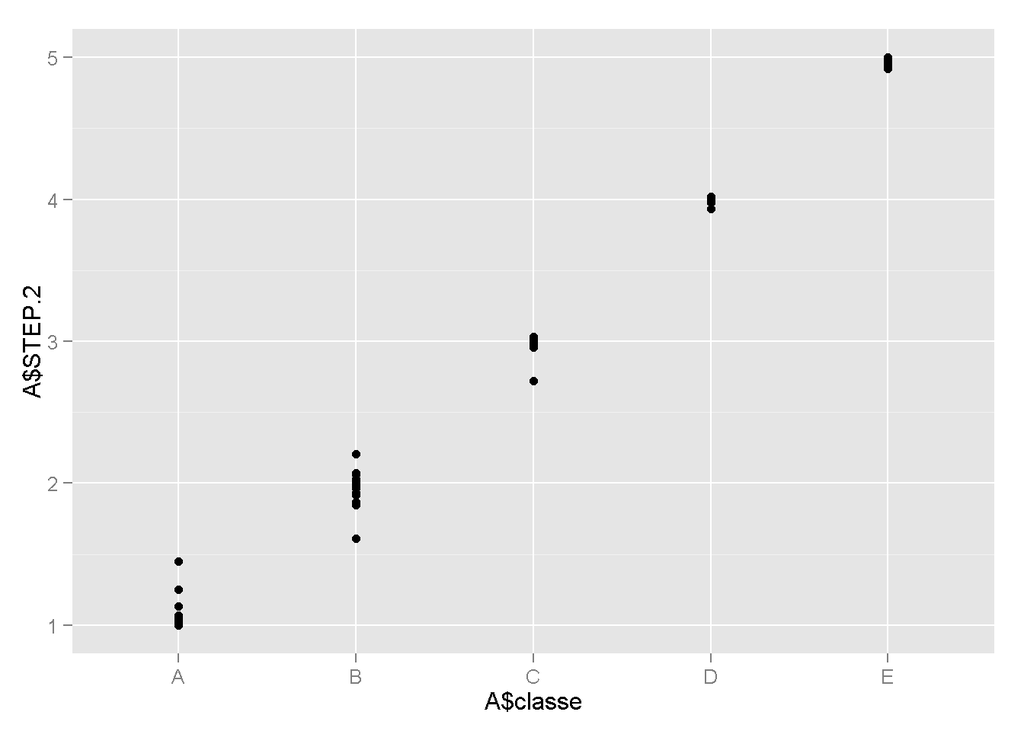

```r
A$classe <- as.factor(A$classe)
qplot(x = A$classe, y = A$STEP.2, data= A)
```

Where A coded like 1, B - like 2, C - 3, D - 4, E - 5.

## 11 Testing the model on the testing part of training data set

So the data of testing part of training set already calculated and we colud just to see the result:

```r
  Middle.Result <- Middle.Result_0
  # calculate the STEP 2 result
  for (i in best.method:best.method) {
    for (j in 1:5) {
      B.selected <- B[which(B$Group==j), ]  # select the current group
      total.row <- nrow(B.selected)
      B.selected <- B.selected[which(B.selected$STEP.2>limits[1,j] & B.selected$STEP.2<=limits[2,j] ), ]
      Middle.Result[j, 2+i] <- nrow(B.selected)/total.row
    }
  }

  Middle.Result3 <- Middle.Result
  Middle.Result3 <- Middle.Result3[, -2]
  add.to.MR2 <- c()

  names(Middle.Result3)[1] <- "Group"
  for (i in 1:methods.length) {
    names(Middle.Result3)[1+i] <- method.names[i]
    Middle.Result3[,1+i] <- Middle.Result3[,1+i]*100
    b <- sum(Middle.Result3[,1+i])/5
    add.to.MR2 <- cbind(add.to.MR2, b)
  }
  add.to.MR2 <- cbind("Average", add.to.MR2)
  add.to.MR2 <- as.data.frame(add.to.MR2)
  names(add.to.MR2) <- names(Middle.Result3)
  for (i in 2:(methods.length+1)) { add.to.MR2[ ,i] <- as.numeric(as.character(add.to.MR2[ ,i]))}
  Middle.Result3 <- rbind(Middle.Result3, add.to.MR2)
  Middle.Result3 <- Middle.Result3[ , c(1,best.method+1) ]

  pander(Middle.Result3)
```

| Group | rf |
| --- | --- |
| A | 98.92 |
| B | 99.21 |
| C | 98.83 |
| D | 99.07 |
| E | 98.89 |
| Average | 98.98 |

I think it’s a realy good result.

## 12 RESULT

```r
Class.As.Char <- function(x) {
  x$classe[which(x$STEP.2>=0 & x$STEP.2<1.5)] <- "A"
  x$classe[which(x$STEP.2>=1.5 & x$STEP.2<2.5)] <- "B"
  x$classe[which(x$STEP.2>=2.5 & x$STEP.2<3.5)] <- "C"
  x$classe[which(x$STEP.2>=3.5  & x$STEP.2<4.5)] <- "D"
  x$classe[which(x$STEP.2>=4.5)] <- "E"
  return(x)
}
A.test<- Class.As.Char(A.test)
```

As expected, the range of models results is quite strong.

Hereafter the final result:

```r
A.test.Result <- c(1:20)
A.test.Result <- as.data.frame(A.test.Result)
A.test.Result <- cbind(A.test.Result, A.test$classe)
A.test.Result <- as.data.frame(t(A.test.Result))
pander(A.test.Result)
```

Table continues below

|  | V1 | V2 | V3 | V4 | V5 | V6 | V7 |
| --- | --- | --- | --- | --- | --- | --- | --- |
| **A.test.Result** | 1 | 2 | 3 | 4 | 5 | 6 | 7 |
| **A.test$classe** | B | A | B | A | A | E | D |

Table continues below

|  | V8 | V9 | V10 | V11 | V12 | V13 |
| --- | --- | --- | --- | --- | --- | --- |
| **A.test.Result** | 8 | 9 | 10 | 11 | 12 | 13 |
| **A.test$classe** | B | A | A | B | C | B |

Table continues below

|  | V14 | V15 | V16 | V17 | V18 | V19 |
| --- | --- | --- | --- | --- | --- | --- |
| **A.test.Result** | 14 | 15 | 16 | 17 | 18 | 19 |
| **A.test$classe** | A | E | E | A | B | B |

|  | V20 |
| --- | --- |
| **A.test.Result** | 20 |
| **A.test$classe** | B |

Special note is the using of multi-threaded calculations. Without using this package, the result would have been much later.

Thanks a lot for your time!